# T7 @BC2 - Preprocessing and clustering

## General workflow

(0. Reading data)

1. QC and filtering
2. Normalization and scaling
3. Dimensionality reduction
4. Clustering and cluster annotation

## Reading data

```r
 dirs <- list.dirs("path/to/cellranger_results", full.names=TRUE)
 names(dirs) <- basename(fastq_dirs)
 sce <- DropletUtils::read10xCounts(dirs)
```

To read data from `alevin`, see the *tximport* package

## The SingleCellExperiment (SCE) class

Based on the *SummarziedExperiment* class:

[figure not shown]

## The SingleCellExperiment (SCE) class

- Single `colData` columns (cell properties) can be accessed through the `$`, or as a whole through `colData(sce)`.
- `rowData` for feature-level data
- `assays(sce)` produces a list of assays; the SCE class also includes the `counts(sce)` (equivalent to `assays(sce)$counts`) and `logcounts(sce)` accessors for specific assays.
- In addition, the SCE can hold information about low-dimensional representations, accessible as named list through `reducedDims(sce)`
- Both classes are compatible with the interactive SE explorer *iSEE* !

… more about [SingleCellExperiment](https://bioconductor.org/packages/3.10/SingleCellExperiment/vignettes/intro)

## Doublets

- when >=2 cells get captured in the same droplet and are sequenced with a single cellular barcode
- While doublets tend to have more reads than singlets, the difference is insufficient to flag them

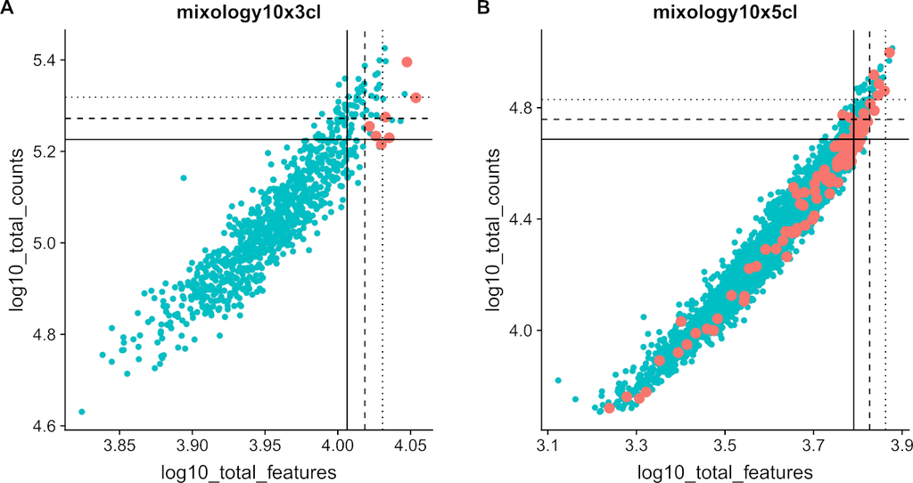

## Doublets

- Doublets created from the same ‘type’, termed *homotypic doublets*, are nearly undetectable
- *neotypic* or *heterotypic doublets* doublets, which combine cells of different types, are potentially problematic but fairly detectable
- Most methods detect doublets through their similarity with artificially-created doublets:
  - scDblFinder is easy to use, efficient and accurate
  - For very large and complex datasets, scds is particularly fast and scalable

```r
 BiocManager::install("testthat")
 BiocManager::install("plger/scDblFinder")
```

## QC and filtering

- The *scater* package is a handy tool for quality control and plotting, working with the SCE class.
- In BioC <3.10, per-cell and per-gene statistics used to be compiled with `calculateQCMetrics()`
- In `devel` (>=3.10), has been replaced with `addQCPerCell()` and `addQCPerFeature()`
- `isOutlier()` can be used to determine cells whose given property is outside a given range from the median

## QC and filtering

- Stringent filters are heavily biased on some cell types
- Cluster-based filters typically remove nothing

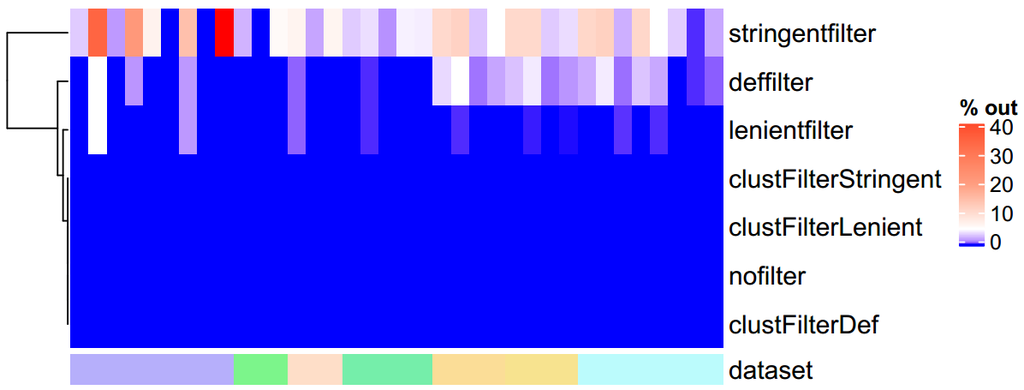

## Seurat

- [Seurat](https://github.com/satijalab/seurat) uses it’s own object class for handling the data
- The `Seurat` class can contain different `assays`, but each assay has 3 `slots`:
  - `raw.data`, `data` (normalized), and `scale.data` (normalized and scaled).
  - The data can be accessed as follows:

```r
 GetAssayData(so, assay="RNA", slot="raw.data")
```

- as with `SCE`, cell metadata can be accessed with `$`

## Seurat workflow(s)

- [Hafermeister and Satija 2019](http://biorxiv.org/lookup/doi/10.1101/576827)
- [Stuart et al. 2018](http://biorxiv.org/lookup/doi/10.1101/460147)

[interactive chart not shown]

## Seurat workflow(s)

[interactive chart not shown]

## Choosing number of dimensions

\(dist(a,b) = \sqrt{ (a_1-b_1)^2 + (a_2-b_2)^2 + ... + (a_k-b_k)^2}\)

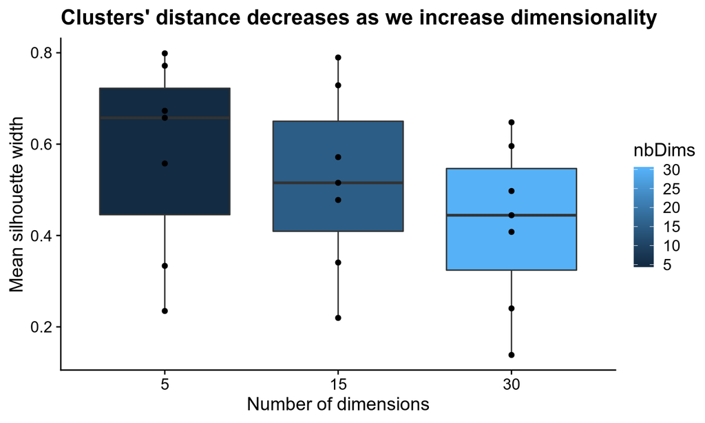

## Choosing number of dimensions

- Example strategies:
  - finding elbow in variance explained
  - Seurat’s JackStraw procedure
  - *scran*’s `denoisePCA`

## Browsing clustering resolutions

[figure not shown]

See the clustree package

## Cluster annotation

- One can use a combination of:
  - relying on known markers
  - look for genes with cluster-specific expression patterns (see for instance `Seurat::FindAllMarker` or `scran::findMarkers`)
- In addition, a variety of methods are being developed to recognize cell types from reference data (e.g. cellassign)